# Laboratory2

# Introduction

Lab 2 will cement a number of R skills and theory related to the following:

1. The empirical rule
2. The Chebyshev rule
3. Transformation of data to z values
4. Location of outliers using z values

# R skills

For the empirical rule you will need to be able to calculate means and standard deviations.

You can make z values in a number of different ways.

## Z, Method 1

Suppose we wish to make Z values from the DDT variable in the `ddt` data frame.

```r
d <- ddt$DDT
z <- (d-mean(d))/sd(d)
head(z)
ws#> [1] -0.14591590 -0.08492702 -0.01377332 -0.03410295  0.26067665  1.27715803
```

## Z, Method 2

We can use a built in function called `scale()`

```r
zmat<-scale(ddt$DDT) # scale makes a matrix of z values
z<-zmat[,1] # take the column to form a vector
head(z)
ws#> [1] -0.14591590 -0.08492702 -0.01377332 -0.03410295  0.26067665  1.27715803
```

## Verify Chebyshev and Empirical rules

To show how many data values lie within `k` standard deviations of the mean you will need to count the number of values in an interval

### Making intervals

```r
mn <- mean(ddt$DDT)
sdd <- sd(ddt$DDT)
mp<-c(-1,1)
k<-2

mn+mp*k*sdd
ws#> [1] -172.4022  221.1122
```

### Values within k standard deviations of the mean

We can subset the data frame with `abs(z)<2` and then pull off the DDT column. The function `length` adds up the number of values in the vector

```r
ddl2<-ddt[abs(z)<2,"DDT"]
length(ddl2)/length(ddt$DDT)*100
ws#> [1] 98.61111
```

98.6% of the DDT lies within 2 standard deviations of the mean.

# Dotplot in ggplot

The dotplot is a simple device, we can set bins of a certain size (I will use 1/5 sd(LENGTH)) to break the continuous data into discrete levels.

In addition we will use the `cut()` function to create labels corresponding to regions of LENGTH that are distant from the mean by integral standard deviations.

See the code below:

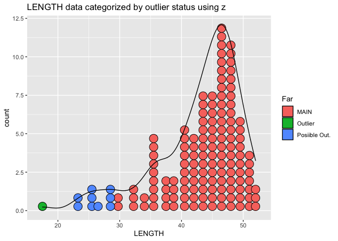

```r
library(ggplot2)
library(dplyr)
mn <- mean(ddt$LENGTH)
sdd <- sd(ddt$LENGTH)
ddt <- ddt %>% mutate( z = (LENGTH-mn)/sdd,
                       Far = ifelse(abs(z)> 3, "Outlier",
                                    ifelse(abs(z)>=2 & abs(z)<=3,
                                           "Posiible Out.", "MAIN")))
g <- ggplot(ddt, aes(x = LENGTH)) + geom_dotplot(aes(fill = Far),binwidth = 1/5*sdd)
g <- g + geom_density(aes(y = ..count..))
g <- g + labs(title = "LENGTH data categorized by outlier status using z")
g
```

Or we could just *cut* the LENGTH variable as below:

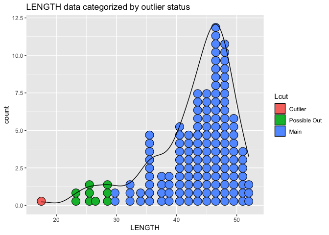

```r
library(ggplot2)
library(dplyr)
mn <- mean(ddt$LENGTH)
sdd <- sd(ddt$LENGTH)
ddt <- ddt %>% mutate( Lcut = cut(LENGTH, c(min(LENGTH)-1,
                                            seq(mn-3*sdd, mn+3*sdd, by = sdd), max(LENGTH)),
                                  labels = c("Outlier","Possible Out","Main","Main", "Main","Main", "Possible Out", "Outlier")))
g <- ggplot(ddt, aes(x = LENGTH)) + geom_dotplot(aes(fill = Lcut),binwidth = 1/5*sdd)
g <- g + geom_density(aes(y = ..count..))
g <- g + labs(title = "LENGTH data categorized by outlier status")
g
```

# Instructions

You will need the following files

```r
dir(dirdl)
ws#> [1] "EPAGAS.XLS"               "MATH4753Laboratory2.docx"
ws#> [3] "lab2.R"
```

Make sure you place them all in Lab2.

EPAGAS

Lab2.R

Lab document